# General Linear Models: Count Outcome

Evan Carey, created for BH Analytics

# The General Linear Model

- We can generalize the ordinary linear model to a more flexible framework
- In regular regression, the predictor variables are on the same scale as the outcome
- We assume a normal distribution

$$E(X) = B_{0} + B_{1}*X_{1} + B_{2}*X_{2} + ... + B_{k}*X_{k} + e$$

- A more general framework would be to allow some function to link the predictors to the outcome
- This is called the link function, and in normal regression it is identity
- We can also consider different distributional families for the outcome
- The combination of the link function and the distributional family is the general linear model

# Poisson Regression

$$ln(\lambda) = B_{0} + B_{1}*X_{1} + B_{2}*X_{2} + ... + B_{k}*X_{k}$$

- In Poisson regression, we are modeling a count outcome
- The distributional family we use is the Poisson distribution, where the mean is equal to the variance
- The only parameter is therefore lambda ($\lambda$)
- The link function is simply log
- Predictors are on the log scale here

# Poisson Regression

- What is our target of inference in this model?
- Where is the error term?

# The Poisson Distribution

- You can get a better sense of the Poisson distribution by visualizing the PDF. Considering you can use the `dpois()` function to map the height of the density at various locations, can you figure out how to make a density for different values of lambda between 0 and 10?

> Hint: here is how to do it for lambda = 0.5

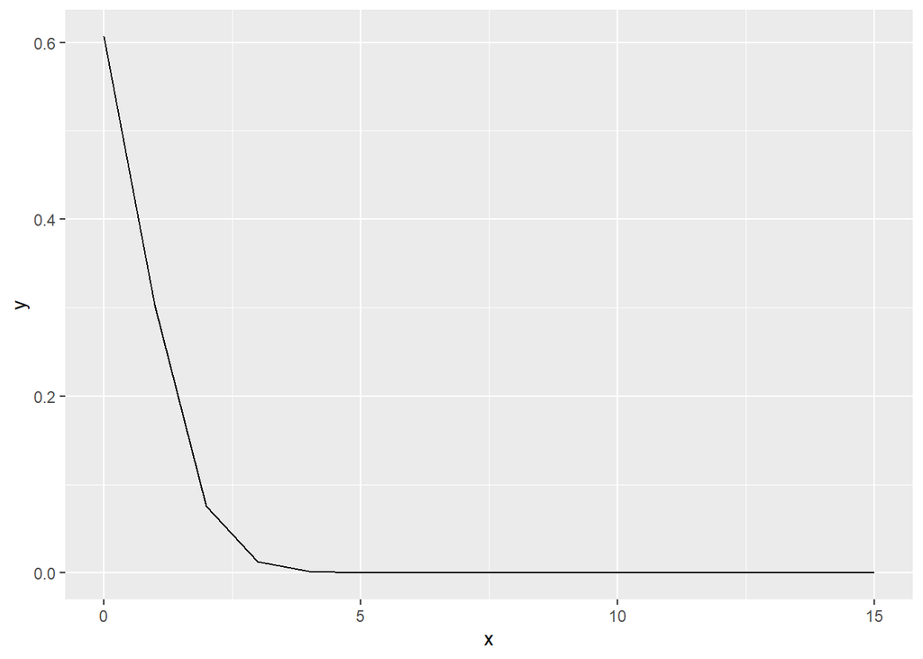

```r
x=0:15
y=dpois(x,lambda = 0.5)
library(ggplot2)
qplot(x,y,geom = 'line')
```

# The Poisson Distribution

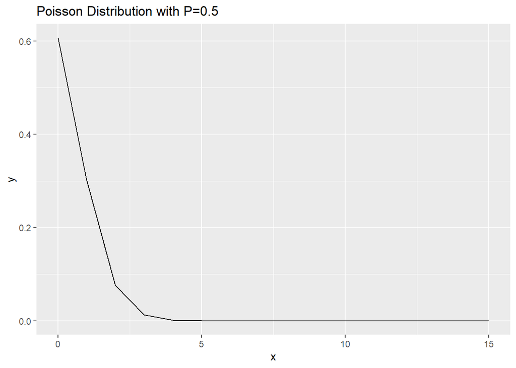

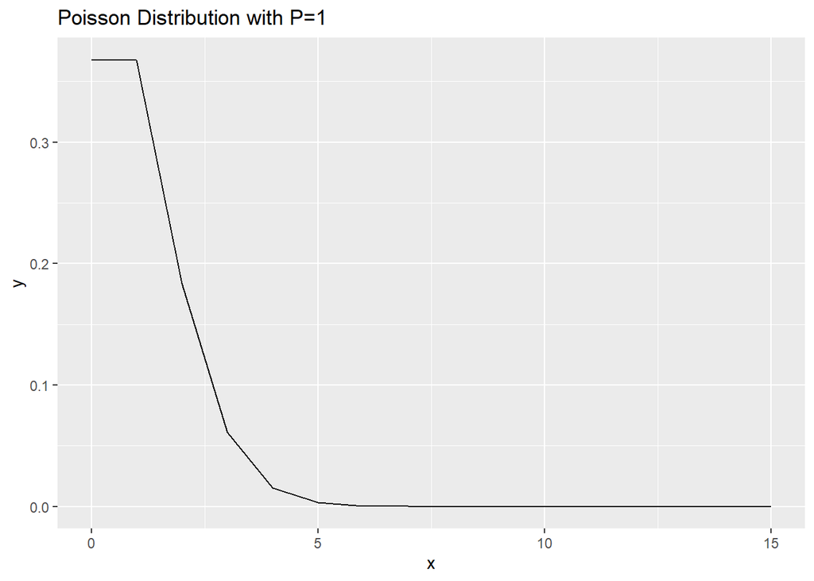

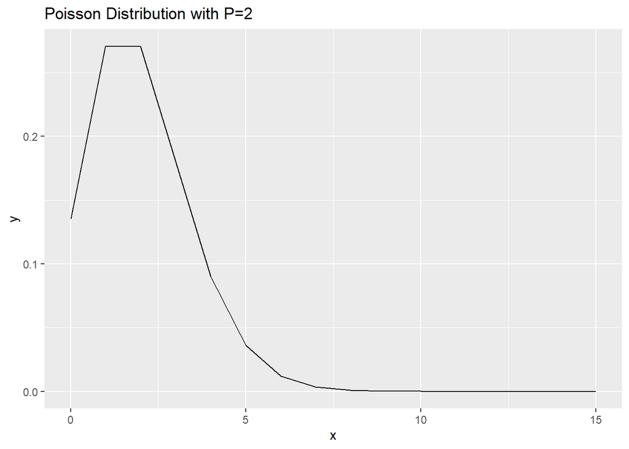

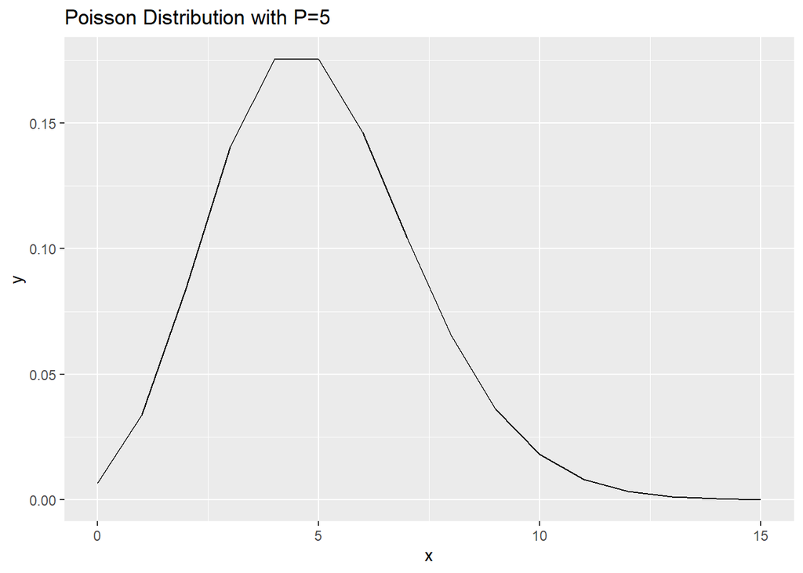

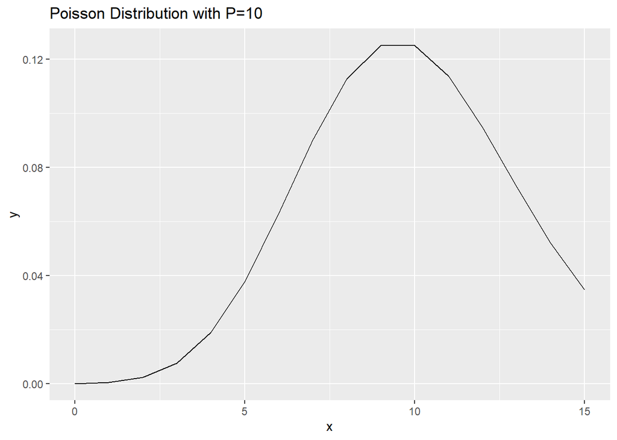

```r
for (i in c(0.5,1,2,5,10)){
  y=dpois(x,lambda = i)
  print(qplot(x,y,geom = 'line',
              main=paste0('Poisson Distribution with P=',i)))
  }
```

# Poisson Regression: Epilepsy data

- We will use the epilepsy dataset for this exercise
- As always, first inspect your data!

```r
library(HSAUR3)
library(Hmisc)
## Check epilepsy data
data("epilepsy")
?epilepsy
head(epilepsy)
```

```
##     treatment base age seizure.rate period subject
## 1     placebo   11  31            5      1       1
## 110   placebo   11  31            3      2       1
## 112   placebo   11  31            3      3       1
## 114   placebo   11  31            3      4       1
## 2     placebo   11  30            3      1       2
## 210   placebo   11  30            5      2       2
```

```r
# Check the distribution of all variables
describe(epilepsy)
```

```
## epilepsy
##
##  6  Variables      236  Observations
## -----------------------------------------------------------------------------------------------------------------------------------------------------
## treatment
##        n  missing distinct
##      236        0        2
##
## Value        placebo Progabide
## Frequency        112       124
## Proportion     0.475     0.525
## -----------------------------------------------------------------------------------------------------------------------------------------------------
## base
##        n  missing distinct     Info     Mean      Gmd      .05      .10      .25      .50      .75      .90      .95
##      236        0       39    0.999    31.22    25.93     7.75     9.50    12.00    22.00    41.00    61.00    78.75
##
## lowest :   6   7   8   9  10, highest:  67  76  87 111 151
## -----------------------------------------------------------------------------------------------------------------------------------------------------
## age
##        n  missing distinct     Info     Mean      Gmd      .05      .10      .25      .50      .75      .90      .95
##      236        0       22    0.996    28.34    7.169    19.75    21.00    23.00    28.00    32.00    36.50    40.00
##
## lowest : 18 19 20 21 22, highest: 36 37 40 41 42
## -----------------------------------------------------------------------------------------------------------------------------------------------------
## seizure.rate
##        n  missing distinct     Info     Mean      Gmd      .05      .10      .25      .50      .75      .90      .95
##      236        0       36    0.993    8.263    9.588     0.00     1.00     2.75     4.00     9.00    19.00    25.25
##
## lowest :   0   1   2   3   4, highest:  63  65  72  76 102
## -----------------------------------------------------------------------------------------------------------------------------------------------------
## period
##        n  missing distinct
##      236        0        4
##
## Value         1    2    3    4
## Frequency    59   59   59   59
## Proportion 0.25 0.25 0.25 0.25
## -----------------------------------------------------------------------------------------------------------------------------------------------------
## subject
##        n  missing distinct
##      236        0       59
##
## lowest : 1  2  3  4  5 , highest: 55 56 57 58 59
## -----------------------------------------------------------------------------------------------------------------------------------------------------
```

# Epilepsy Data

- Recall a key assumption of the Poisson distribution - the mean is equal to the variance. Is that true here?

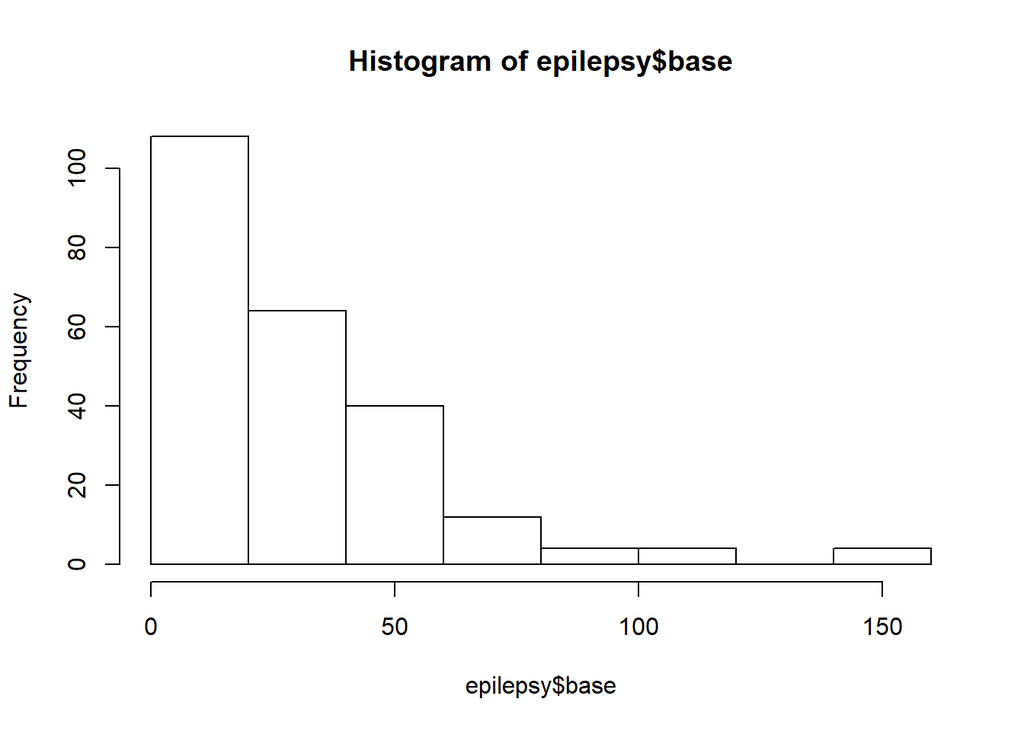

```r
# Is the mean equal to the variance?
hist(epilepsy$base)
```

```r
mean(epilepsy$base)
```

```
## [1] 31.22034
```

```r
var(epilepsy$base)
```

```
## [1] 713.1598
```

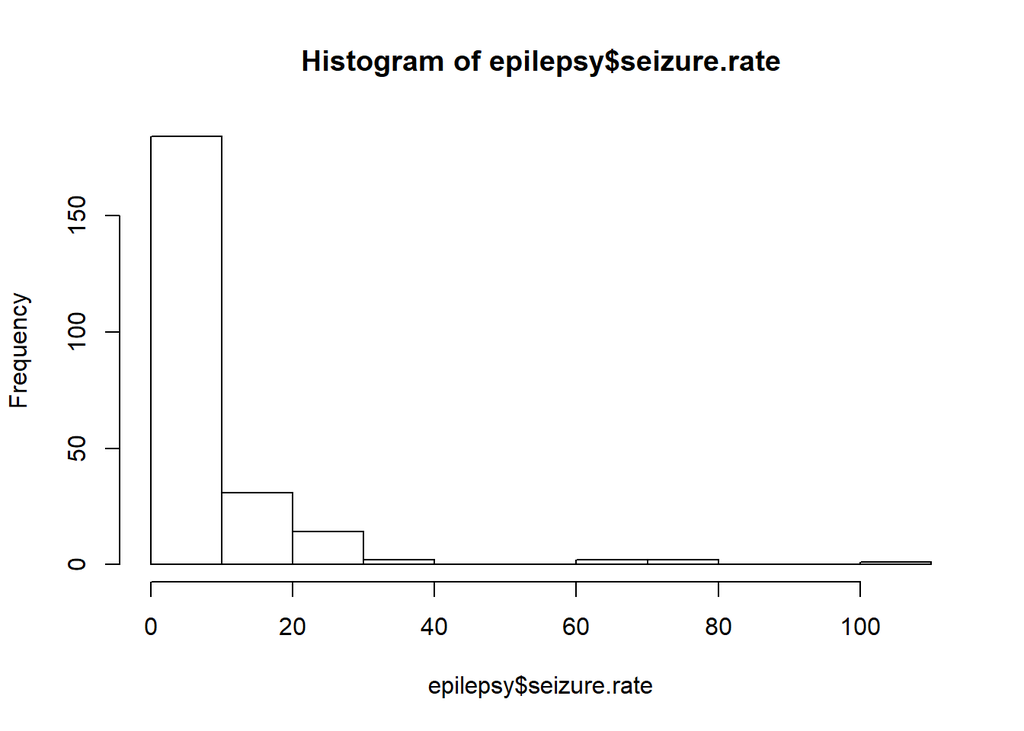

```r
# What about during the trial?
hist(epilepsy$seizure.rate)
```

```r
mean(epilepsy$seizure.rate)
```

```
## [1] 8.262712
```

```r
var(epilepsy$seizure.rate)
```

```
## [1] 152.6796
```

# Null Model

- The first Poisson model we might fit is the null model, that is a model with only an intercept.
- What are we predicting here?

```r
library(rstanarm)
CHAINS = 4
SEED = 42

## Run Initial Null Model
mod0 <- stan_glm(base ~ 1,
                 data=epilepsy,
                 family = poisson(link = "log"),
                 chains=CHAINS, seed=SEED,
                 prior_intercept = normal(0,10))
## examine results
summary(mod0, digits = 3)
```

```
##
## Model Info:
##  function:     stan_glm
##  family:       poisson [log]
##  formula:      base ~ 1
##  algorithm:    sampling
##  sample:       4000 (posterior sample size)
##  priors:       see help('prior_summary')
##  observations: 236
##  predictors:   1
##
## Estimates:
##               mean   sd    10%   50%   90%
## (Intercept) 3.441  0.011 3.426 3.441 3.456
##
## Fit Diagnostics:
##            mean   sd     10%    50%    90%
## mean_PPD 31.210  0.519 30.534 31.212 31.878
##
## The mean_ppd is the sample average posterior predictive distribution of the outcome variable (for details see help('summary.stanreg')).
##
## MCMC diagnostics
##               mcse  Rhat  n_eff
## (Intercept)   0.000 1.001 1458
## mean_PPD      0.011 1.000 2154
## log-posterior 0.022 1.003 1035
##
## For each parameter, mcse is Monte Carlo standard error, n_eff is a crude measure of effective sample size, and Rhat is the potential scale reduction factor on split chains (at convergence Rhat=1).
```

```r
exp(coef(mod0))
```

```
## (Intercept)
##    31.22617
```

- How would you interpret this number?

# Adding Additional predictors into this model

- Let’s examine the general relationship between age and the number of seizures during the baseline period.

```r
## Age baseline model
mod1 <- stan_glm(base ~ age,
                 data=epilepsy,
                 family = poisson(link = "log"),
                 chains=CHAINS, seed=SEED,
                 prior = normal(0,2.5),
                 prior_intercept = normal(0,10))
## examine results
summary(mod1, digits = 3)
```

```
##
## Model Info:
##  function:     stan_glm
##  family:       poisson [log]
##  formula:      base ~ age
##  algorithm:    sampling
##  sample:       4000 (posterior sample size)
##  priors:       see help('prior_summary')
##  observations: 236
##  predictors:   2
##
## Estimates:
##               mean   sd     10%    50%    90%
## (Intercept)  4.181  0.053  4.114  4.181  4.249
## age         -0.027  0.002 -0.029 -0.027 -0.024
##
## Fit Diagnostics:
##            mean   sd     10%    50%    90%
## mean_PPD 31.219  0.512 30.559 31.229 31.877
##
## The mean_ppd is the sample average posterior predictive distribution of the outcome variable (for details see help('summary.stanreg')).
##
## MCMC diagnostics
##               mcse  Rhat  n_eff
## (Intercept)   0.001 1.000 3542
## age           0.000 1.000 3272
## mean_PPD      0.012 1.001 1695
## log-posterior 0.027 1.005 1273
##
## For each parameter, mcse is Monte Carlo standard error, n_eff is a crude measure of effective sample size, and Rhat is the potential scale reduction factor on split chains (at convergence Rhat=1).
```

- How would you interpret these results?
- Should we consider a non-linear function of age here?
- Let’s look at a scatterplot of the two variables to get a better sense of the potential relationship.

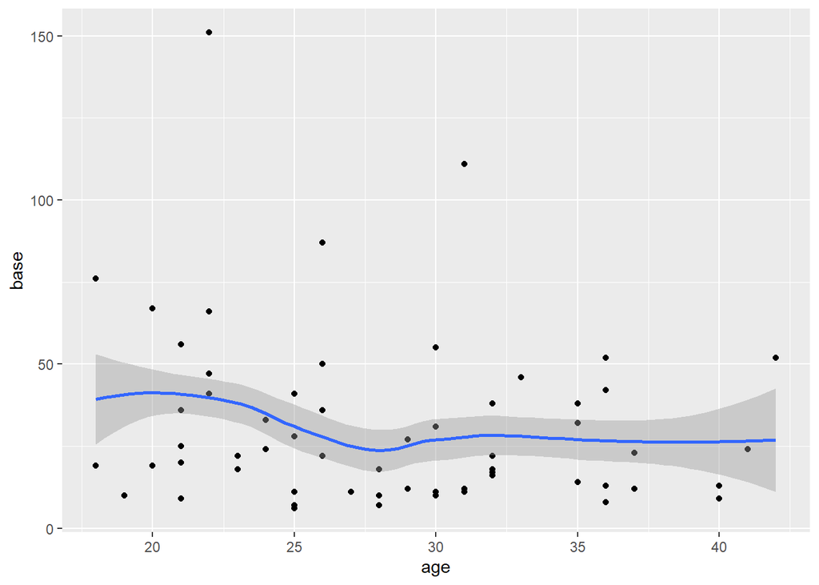

```r
library(ggplot2)
ggplot(epilepsy, aes(x=age,y=base)) +
  geom_point() +
  geom_smooth()
```

# Assessing model Fit

- Since we have a posterior distribution that is generative, one way to check the model fit is to generate data from our model, and compare it with the original dataset. We can do this using the `pp_check()` function.

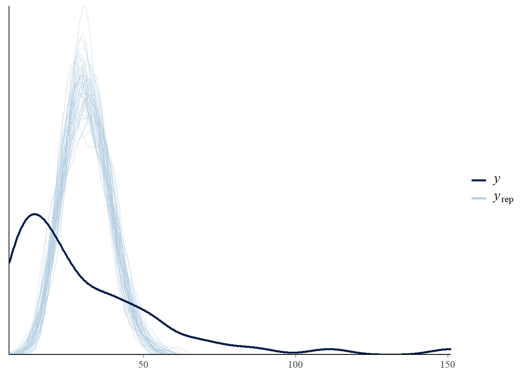

```r
# Check the model fit
pp_check(mod1)
```

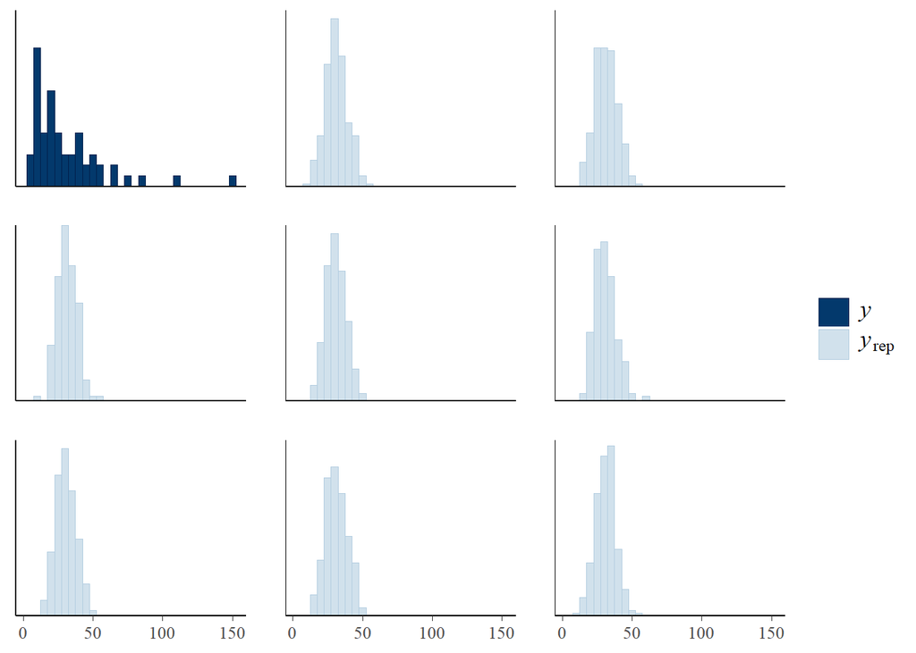

```r
pp_check(mod1, plotfun='hist')
```

# The Negative Binomial Distribution

- One solution to the issue of overdispersion is to fit a negative binomial model. This model allows for the variance to be unequal to the mean.
- This distribution is typically used to describe the number of successes in a sequence until a failure occurs, when the sequence of events are independent and identically distributed Bernoulli trials [link](https://en.wikipedia.org/wiki/Negative_binomial_distribution)
- In the case of overdispersed count outcomes, we can use the negative binomial distribution to relax the assumption of mean equals Variance in the Poisson.

```r
## fit negative binomial
mod0nb <- stan_glm(base ~ 1,
                 data=epilepsy,
                 family = neg_binomial_2(link = 'log'),
                 prior_intercept = normal(0,10),
                 prior_aux = cauchy(0,5),
                 chains=CHAINS, seed=SEED)
## examine results
summary(mod0nb, digits = 3)
```

```
##
## Model Info:
##  function:     stan_glm
##  family:       neg_binomial_2 [log]
##  formula:      base ~ 1
##  algorithm:    sampling
##  sample:       4000 (posterior sample size)
##  priors:       see help('prior_summary')
##  observations: 236
##  predictors:   1
##
## Estimates:
##                         mean   sd    10%   50%   90%
## (Intercept)           3.441  0.048 3.380 3.441 3.502
## reciprocal_dispersion 2.000  0.179 1.782 1.991 2.231
##
## Fit Diagnostics:
##            mean   sd     10%    50%    90%
## mean_PPD 31.273  2.114 28.627 31.212 33.963
##
## The mean_ppd is the sample average posterior predictive distribution of the outcome variable (for details see help('summary.stanreg')).
##
## MCMC diagnostics
##                       mcse  Rhat  n_eff
## (Intercept)           0.001 1.001 2477
## reciprocal_dispersion 0.004 1.001 2598
## mean_PPD              0.039 1.001 2963
## log-posterior         0.024 1.001 1727
##
## For each parameter, mcse is Monte Carlo standard error, n_eff is a crude measure of effective sample size, and Rhat is the potential scale reduction factor on split chains (at convergence Rhat=1).
```

- Considering this is a log link function, we can interpret the coefficients similarly as we did in the Poisson regression. In the case of this intercept only model, we can exponentiate the intercept to get the expected count (mean) for the data.

```r
coef(mod0nb)
```

```
## (Intercept)
##    3.440905
```

```r
exp(coef(mod0nb))
```

```
## (Intercept)
##     31.2152
```

# Assessing model Fit

- Since we have a posterior distribution that is generative, one way to check the model fit is to generate data from our model, and compare it with the original dataset. We can do this using the `pp_check()` function.

> Question: Do you think the model fit is better for this distribution? Use the `pp_check()` function to find out.

# Assessing model Fit

- Since we have a posterior distribution that is generative, one way to check the model fit is to generate data from our model, and compare it with the original dataset. We can do this using the `pp_check()` function.

> Question: Do you think the model fit is better for this distribution? Use the `pp_check()` function to find out.

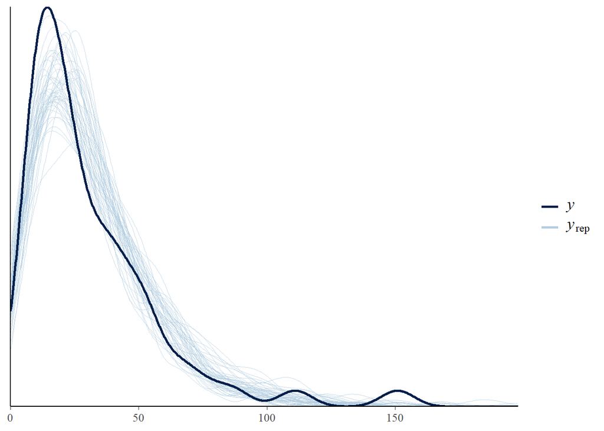

```r
# Check the model fit
pp_check(mod0nb)
```

# Multivariate Negative Binomial

- Let’s say we are interested in checking to see if there was any difference in the baseline seizure rate across our treatment groups, as this would indicate a source of bias in the study.
- We can proceed with our model as we typically do in R, adding predictors via the formula

```r
## fit negative binomial with treatment
mod1nb <- stan_glm(base ~ treatment,
                 data=epilepsy,
                 family = neg_binomial_2(link = 'log'),
                 prior_intercept = normal(0,10),
                 prior_aux = cauchy(0,5),
                 chains=CHAINS, seed=SEED)
## examine results
summary(mod1nb, digits = 3)
```

```
##
## Model Info:
##  function:     stan_glm
##  family:       neg_binomial_2 [log]
##  formula:      base ~ treatment
##  algorithm:    sampling
##  sample:       4000 (posterior sample size)
##  priors:       see help('prior_summary')
##  observations: 236
##  predictors:   2
##
## Estimates:
##                         mean   sd     10%    50%    90%
## (Intercept)            3.428  0.069  3.343  3.427  3.516
## treatmentProgabide     0.027  0.096 -0.094  0.027  0.154
## reciprocal_dispersion  1.992  0.179  1.764  1.986  2.230
##
## Fit Diagnostics:
##            mean   sd     10%    50%    90%
## mean_PPD 31.365  2.095 28.753 31.333 34.005
##
## The mean_ppd is the sample average posterior predictive distribution of the outcome variable (for details see help('summary.stanreg')).
##
## MCMC diagnostics
##                       mcse  Rhat  n_eff
## (Intercept)           0.001 0.999 3658
## treatmentProgabide    0.002 1.000 3684
## reciprocal_dispersion 0.003 1.000 3577
## mean_PPD              0.034 1.000 3858
## log-posterior         0.028 1.000 1928
##
## For each parameter, mcse is Monte Carlo standard error, n_eff is a crude measure of effective sample size, and Rhat is the potential scale reduction factor on split chains (at convergence Rhat=1).
```

- Let’s check our model:

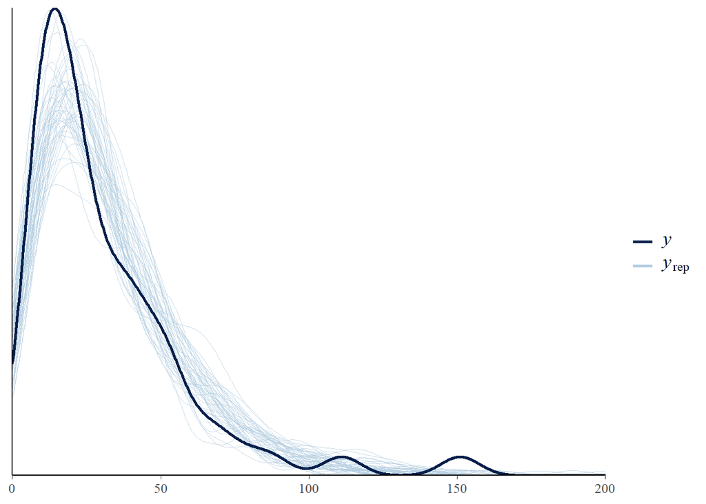

```r
pp_check(mod1nb)
```

> Question: How would you interpret these models results? What is the expected count of seizures of a patient in the trial both with and without treatment?

# Predicting Outcomes for Patients

- Here are the model results, and the corresponding exponentiated parameters.

```r
exp(coef(mod1nb))
```

```
##        (Intercept) treatmentProgabide
##          30.772095           1.027855
```

```r
exp(posterior_interval(mod1nb))
```

```
##                               5%       95%
## (Intercept)           27.5702409 34.489981
## treatmentProgabide     0.8808376  1.207429
## reciprocal_dispersion  5.4937972  9.990342
```

```r
df1 <- data.frame(treatment=c('Progabide', 'placebo'))
# Get estimates on the scale of the outcome with Transform=T
df1_posterior <- posterior_epred(mod1nb,newdata = df1)
colnames(df1_posterior) <- c('Progabide', 'placebo')
apply(df1_posterior,2, quantile, probs=c(0.05,0.5,0.95))
```

```
##
##       Progabide  placebo
##   5%   28.40240 27.57024
##   50%  31.67903 30.77210
##   95%  35.29227 34.48998
```

# Exercises with this Data

- I want you to analyze the results of this clinical trial using what you have learned above. You should answer the question, does treatment change the expected number of seizures for these patients? Produce the estimate change and variance for both the average change, and the actual predicted change for individual patients.
- You should consider a potential interaction of treatment effect with age
- You may ignore the longitudinal nature of this data for now (that would require using group effects, more on this to come!)